# Alternative Text

Liza Dubinsky

3/11/2022

## Load packages and data

```r
library(tidyverse)
library(openintro)
install.packages("countrycode")
library(countrycode)
```

STATISTICS SECTION/REAL WORLD GROUND-IN

```r
chocolate <- readr::read_csv('https://raw.githubusercontent.com/rfordatascience/tidytuesday/master/data/2022/2022-01-18/chocolate.csv')
penguins <- readr::read_csv('https://raw.githubusercontent.com/rfordatascience/tidytuesday/master/data/2020/2020-07-28/penguins.csv')
```

```r
chocolate <- chocolate %>%
  mutate(continent = countrycode(country_of_bean_origin, origin  = "country.name", destination = "continent"))
```

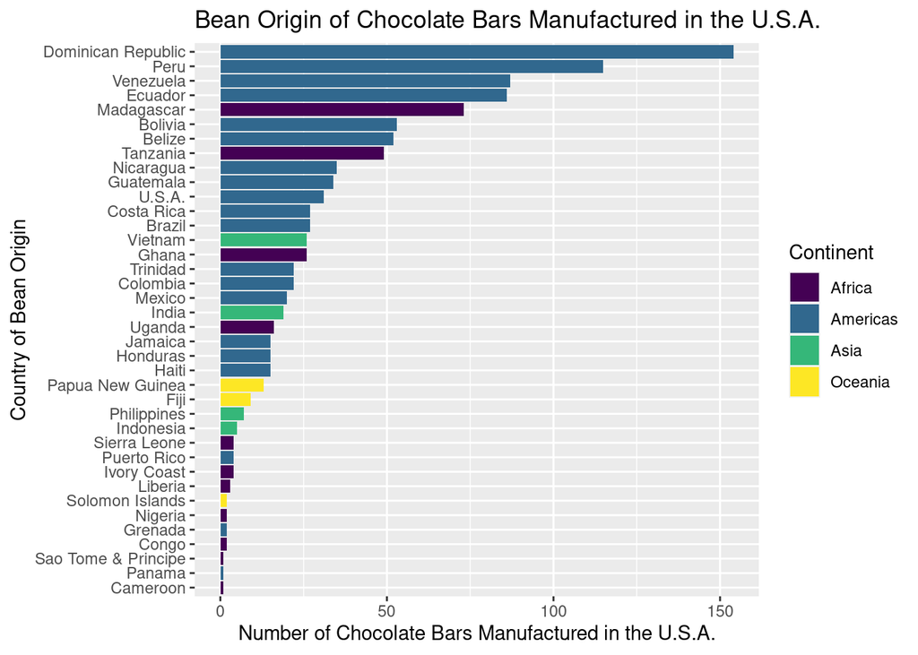

```r
chocolate %>%
  #narrow down to specific continent
  filter(company_location == "U.S.A.", country_of_bean_origin != "Blend") %>%
  group_by(country_of_bean_origin, continent) %>%
  summarise(count = n()) %>%
  #summarise(mean_cocoa_percent = mean(as.numeric(substr(cocoa_percent, start = 1, stop = 2)), na.rm = TRUE)) %>%
  ggplot(mapping = aes(x = fct_reorder(country_of_bean_origin, count), y = count, fill = continent)) +
  geom_col() +
  coord_flip() +
  labs(title = "Bean Origin of Chocolate Bars Manufactured in the U.S.A.", y = "Number of Chocolate Bars Manufactured in the U.S.A.", x = "Country of Bean Origin", fill = "Continent") +
  scale_fill_viridis_d()
```

Exercise 1. Add your response to the RMarkdown file.

With this in mind, which of the four alternative text examples below best describe the above image (justify why each one meets or doesn’t meet standards for alternative text for data visualizations:

1. Bar chart where 20 of the 38 countries are in the Americas, 11 of the 38 countries are in Africa, and the Dominican Republic, Peru, Venezuela, and Ecuador are the top four countries responsible for 154, 115, 87, and 86 bars respectively.
2. Bar chart of the number of chocolate bars manufactured in the U.S.A by country and continent of bean origin where 20 of the 38 countries are in the Americas, 11 of the 38 countries are in Africa, and the Dominican Republic, Peru, Venezuela, and Ecuador are the top four countries responsible for 154, 115, 87, and 86 bars respectively.
3. Bar chart of the number of chocolate bars manufactured in the U.S.A by country and continent of bean origin.
4. Number of chocolate bars manufactured in the U.S.A by country and continent of bean origin where 20 of the 38 countries are in the Americas, 11 of the 38 countries are in Africa, and the Dominican Republic, Peru, Venezuela, and Ecuador are the top four countries responsible for 154, 115, 87, and 86 bars respectively.

Making sure your data visualizations are accessible also requires considering the colors you use. Please read WebAIM’s guide on Contrast and Color Accessibility: (https://webaim.org/articles/contrast/#ratio)

Exercise 2. Add your response to the RMarkdown file and justify your choice.

With that understanding, which of the following three dichromatic color palettes is the most accessible in terms of contrast? You may use the WebAIM contrast checker: (https://webaim.org/resources/contrastchecker/).

1. #E0E0E0 and #F5F5F5
2. #AE1313 and #525252
3. #19CCF0 and #262626

Visualizations should be accessible to those with color blindness, which affects roughly 300 million people worldwide. According to CR Ferreira, there are 2 important steps to ensure that those with color blindness can understand your visualization: (https://towardsdatascience.com/two-simple-steps-to-create-colorblind-friendly-data-visualizations-2ed781a167ec).

Exercise 3. Add your response to the RMarkdown file.

After reading Ferreira’s article, what are the 2 steps to make visualizations accessible for those with color blindness? Reflect on what you have learned about color accessibility in data visualizations more broadly, and the tools you can use to produce readable visualizations.

ADD THIS AT THE END OF THE LAB TO COMBINE ALL SECTIONS IN ONE APPLICATION.

Now, try your hand at making data visualizations more accessible by focusing on the color palette and alternative text of this data visualization. Remember to include the chart type, type of data, and reason for including the chart in your alternative text:

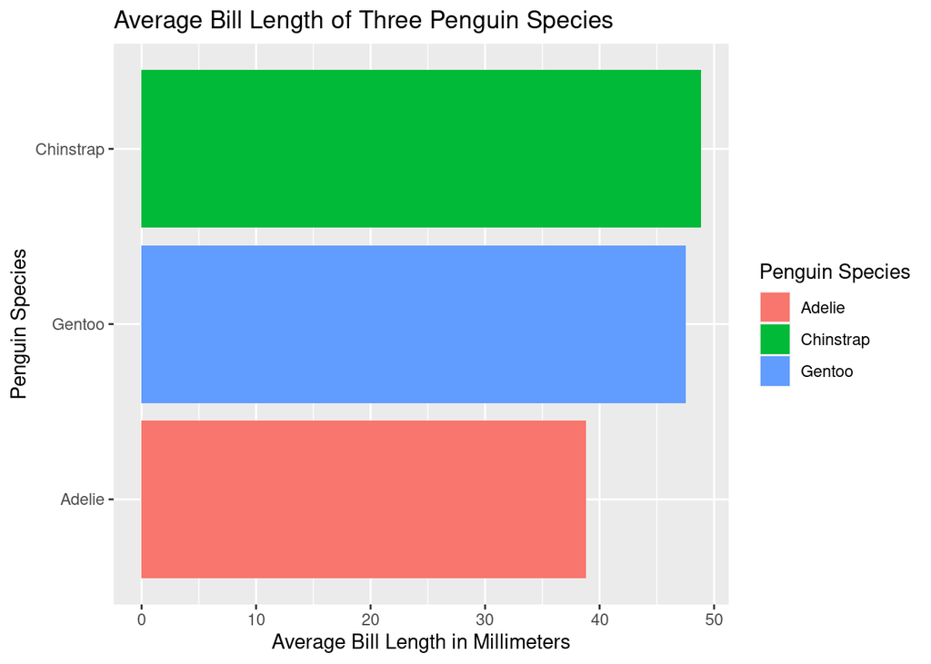

```r
penguins %>%
  group_by(species) %>%
  summarise(mean_bill = mean(bill_length_mm, na.rm = TRUE)) %>%
  ggplot(mapping = aes(x = fct_reorder(species, mean_bill), y = mean_bill, fill = species)) +
  geom_col() +
  coord_flip() +
  labs(title = "Average Bill Length of Three Penguin Species", x = "Penguin Species", y = "Average Bill Length in Millimeters", fill = "Penguin Species")
```

Exercise 3: Add your response to the RMarkdown file.

Compare your color palette and alternative text for this data visualization with others in your group. As a group, combine your ideas to decide on the final data visualization.

Exercise 4: Add your response to the RMarkdown file.

Reflection: i.e. (what’s difficult about applying this criteria to more complex visualizations, what purpose do these elements provide for you as the creator of data visualizations as well as your audience, objectivity)

Choose your own adventure ideas: Homeworks and labs are missing alternative text, choose a plot and write alternative text (link to which visualization you’re working on) – contributing to accessibility of assignments used in the future